# Title: “Figures for Photogrammetry-CAFI manuscript”

author: “Joseph Curtis (modifying code by Journ Galvan)” date: “9/8/2020” output: html_document —

# Overview

The purpose of this document is to outline some preliminary results and interpretation of data collected in Moorea, French Polynesia, regarding the relative utility of measuring coral colonies via photogrammetry versus traditional manual measurements.

# Glossary/formulas

$Volume_{photo}$: Volume calculated through photogrammetry of live coral surface (base, epoxy, and background cropped) $(cm^3)$

$Volume_{hull}$: Volume of convex hull, or the greatest possible volume of coral object $(cm^3)$

$SA_{photo}$: Surface Area from photogrammetry models, only includes live coral surface, not underside of base $(cm^2)$

$SA_{hull}$: Surface Area from convex hull, lowest possible surface area of coral $(cm^2)$

**Interstitial space**: $Volume_{hull}$ - $Volume_{photo}$; higher value means more empty space in convex hull volume $(cm^3)$

**SA/V**: $SA_{photo}$/$Volume_{photo}$ (both from photogrammetry); proxy for rugosity, higher values mean more complex coral structure

**Convexity**: $Volume_{photo}$ / $Volume_{hull}$; proportion of convex hull occupied by object, lower values indicate more empty space inside convex hull. In a coral, this could be due to wide branch distance or higher complexity structure (convoluted, deep interstitial spaces)

**Packing**: $SA_{photo}$ / $SA_{hull}$; another measurement of rugosity and complexity, higher values suggest more structural complexity

**Sphericity**: ${\pi^{1/3}}*(6*Volume_{photo}^{2/3})/(SA_{photo})$; the degree to which the shape of a coral resembles a sphere - higher value means more spherical.

**Branch Width**: Average distance between the vertices of two branches on a coral. In this case, measurements were made at 5 locations per colony using photogrammetry and averaged. Manual measurements of branch distance for these corals would have been possible, but weren’t made.

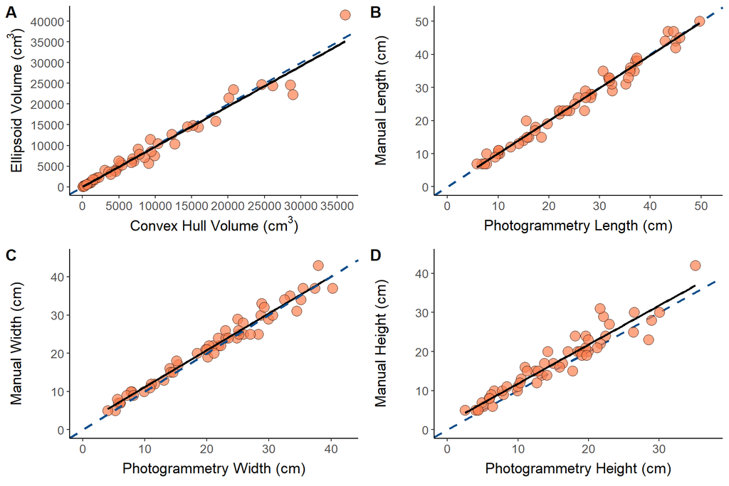

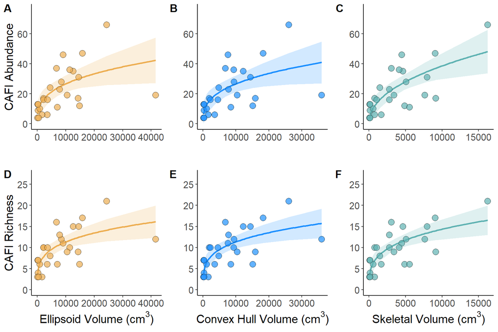

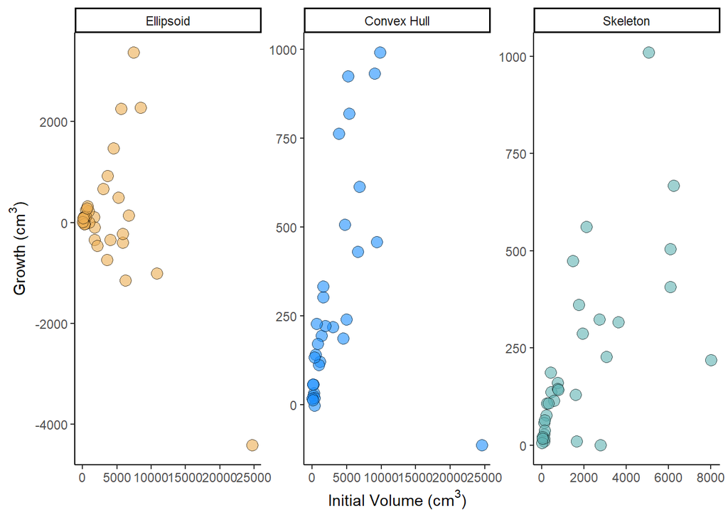

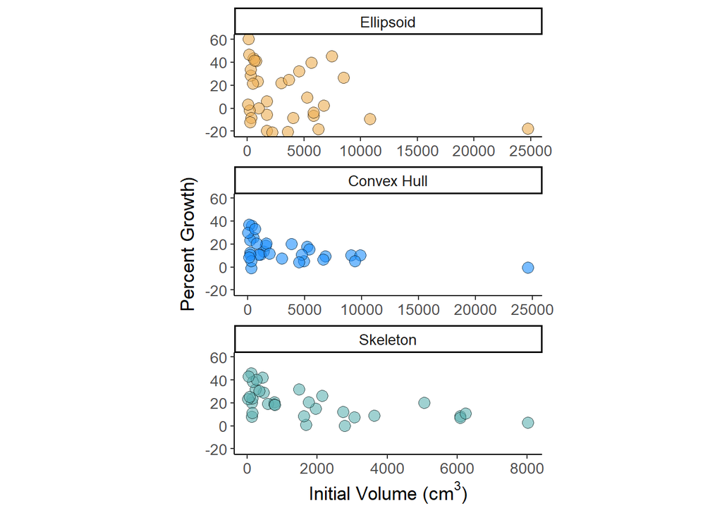

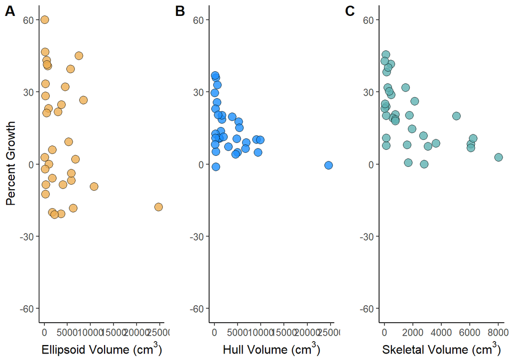

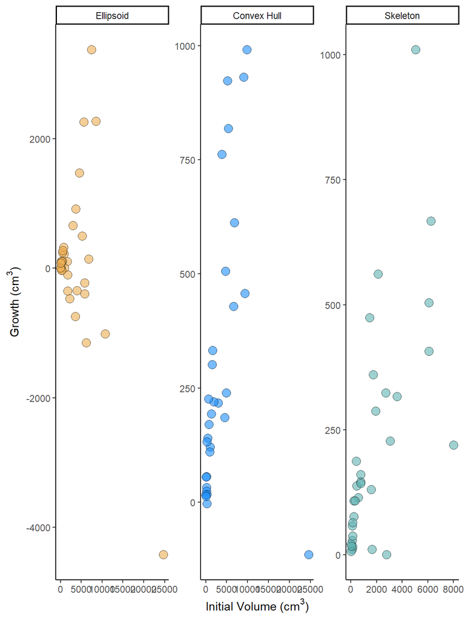

```r
tbl_1
```

| Variable | a | SE_a | t_a | p_a | b | SE_b | t_b | p_b | AIC | RMSE |
| --- | --- | --- | --- | --- | --- | --- | --- | --- | --- | --- |
| **Abundance** |  |  |  |  |  |  |  |  |  |  |
| Ellipse | 1.36 | 1.31 | 1.03 | 0.312 | 0.323 | 0.104 | 3.11 | 0.00477 | 207.55 | 11.67 |
| Convex Hull | 1.23 | 1.23 | 0.999 | 0.328 | 0.334 | 0.107 | 3.11 | 0.00475 | 207.38 | 11.633 |
| Skeletal Volume | 0.578 | 0.557 | 1.04 | 0.311 | 0.456 | 0.111 | 4.1 | <0.001 | 201.76 | 10.441 |
| **Richness** |  |  |  |  |  |  |  |  |  |  |
| Ellipse | 1.17 | 0.66 | 1.77 | 0.0887 | 0.247 | 0.0614 | 4.01 | <0.001 | 141.42 | 3.2718 |
| Convex Hull | 1.1 | 0.625 | 1.76 | 0.0907 | 0.253 | 0.0618 | 4.1 | <0.001 | 140.68 | 3.2251 |
| Skeletal Volume | 1.05 | 0.547 | 1.93 | 0.0658 | 0.284 | 0.0615 | 4.61 | <0.001 | 137.8 | 3.0514 |